### Q1

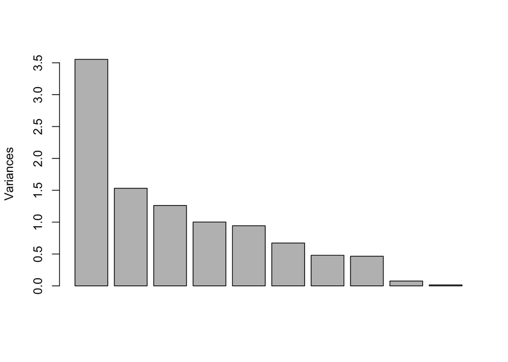

```r
library(MASS)
read.csv('loans-subset.csv')->loans
#First column is an ID number and should be ommitted. Last column is the categorical variable charged off/paid in full
loans.pr<-prcomp(loans[,2:11], scale=TRUE, main="PCA scree plot for scaled loans data", xlab="Component")
plot(loans.pr, main="")
```

```r
round(loans.pr$sd^2/sum(loans.pr$sd^2),2)
```

```
##  [1] 0.36 0.15 0.13 0.10 0.09 0.07 0.05 0.05 0.01 0.00
```

```r
loans.pr$sd
```

```
##  [1] 1.8851347 1.2372841 1.1228323 1.0008233 0.9714489 0.8200176 0.6930065
##  [8] 0.6820167 0.2757148 0.1242184
```

I have used the correlation matrix (the scale=TRUE option) because the variables are not naturally on the same scale, EG the loan amounts and annual incomes are in the thousands, but years in employment is capped at 10. There is not a clear elbow; 2, 3 or 5 components are probably defensible using this criteria. Because the data is scaled we can also consider the “eigenvalue greater than one rule.” This would suggest 4 components, but with the fourth component having eigenvalue almost exactly 1 and the fifth component a tiny bit less. I will choose 3 components, where there is a drop in the eigenvalues, all eigenvalues are substantially larger than 1, and 63% of the variability has been accounted for. (Students should have referenced at least one of these criteria in their answer.)

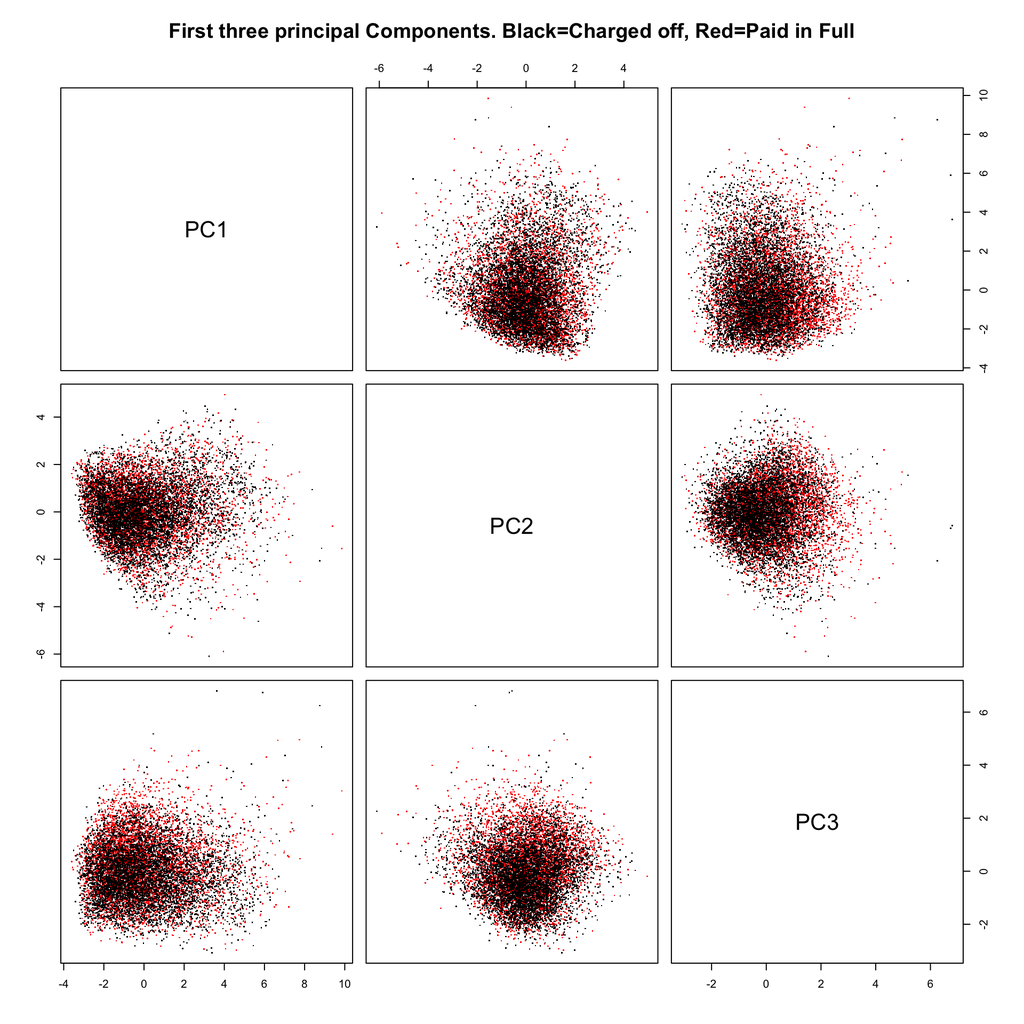

```r
pairs(loans.pr$x[,1:3], col=loans$Loans.loan_status, main='First three principal Components. Black=Charged off, Red=Paid in Full', pch=".")
```

The point clouds are almost entirely overlapping. There are three Charged Off loans with very high values on PC3, but these are obviously a tiny proportion, not a general trend. A 3-D scatter plot is also acceptable here (and equally shows very little pattern.)

### Q2

```r
loans.prscaled<-list(sd=loans.pr$sd[1:3], scores=loans.pr$x[,1:3], loadings=loans.pr$rotation[,1:3])
for(i in 1:3){
  loans.prscaled$loadings[,i]<-loans.prscaled$loadings[,i]*loans.prscaled$sd[i]
  loans.prscaled$x[,i]<-loans.prscaled$x[,i]/loans.prscaled$sd[i]
}
class(loans.prscaled$loadings)<-"loadings"
print(loans.prscaled$loadings,cutoff=.2)
```

```
##
## Loadings:
##                   PC1    PC2    PC3
## Loans.funded_amnt  0.920  0.312
## Loans.loan_amnt    0.916  0.302
## Loans.dti                -0.656 -0.415
## Loans.emp_length   0.302 -0.210  0.370
## Loans.installment  0.903  0.311
## Loans.annual_inc   0.555         0.347
## Loans.revol_bal    0.562 -0.505
## earlyear          -0.396  0.337 -0.527
## proputil                 -0.409 -0.635
## Loans.open_acc     0.360 -0.485  0.273
##
##                  PC1   PC2   PC3
## SS loadings    3.554 1.531 1.261
## Proportion Var 0.355 0.153 0.126
## Cumulative Var 0.355 0.508 0.635
```

If students have simply rounded the loadings (to 2 or 3 decimal places) rather than using the custom print function that is fine, or printed a selection of variables with large (in absolute value) correlations. If small loadings are supressed, sensible cutoffs could be 0.1, 0.2 or 0.3.

### Q3

```r
varimax(loans.prscaled$loadings)->varrot
print(varrot$loadings, cutoff=.2)
```

```
##
## Loadings:
##                   PC1    PC2    PC3
## Loans.funded_amnt  0.971
## Loans.loan_amnt    0.961
## Loans.dti                -0.780
## Loans.emp_length                 0.513
## Loans.installment  0.959
## Loans.annual_inc   0.391         0.514
## Loans.revol_bal    0.267 -0.482  0.518
## earlyear                        -0.736
## proputil                 -0.750
## Loans.open_acc           -0.230  0.621
##
##                  PC1   PC2   PC3
## SS loadings    3.036 1.482 1.827
## Proportion Var 0.304 0.148 0.183
## Cumulative Var 0.304 0.452 0.635
```

It does seem the loadings are more interpretable, with fewer variables where loadings meet the cutoff for each factor. The first factor appears to do with the size of the loan (including the monthly payment.) The second has to do with the size of other loans: their revolving credit balance, the proportion this is of their total credit line, and debt to income ratio. The last component is more murky; it has to do with income, but also the balance on other accounts. The contrast between earlyear (the first year they opened a credit line, with a negative coefficient) and Loans.open_acc, the number of credit lines they have opened, may indicate the total number of credit lines is important only after controling for time–10 credit lines opened over 20 years is different than 10 credit lines opened over 1 year. This may be the function employment length is serving as well.

Reasonable names might be “loan size,” “Other debt”, and “Income and history.”

### Q4

```r
lda(x=loans[,2:11], grouping= loans$Loans.loan_status, CV=TRUE)->loans.lda.cv
table(paste("predicted ",loans.lda.cv$class), loans$Loans.loan_status)
```

```
##
##                          Charged Off Fully Paid
##   predicted  Charged Off        3207       2155
##   predicted  Fully Paid         2218       3270
```

```r
#compute % correct
round(sum(loans.lda.cv$class==loans$Loans.loan_status)/length(loans$Loans.loan_status),2)
```

```
## [1] 0.6
```

OK if you do not have “predicted” in your row labels, but your answer should not make mistakes as to which are the actual and which are the predicted categories. Here, we have predicted 60% correctly. Random guessing would give us about 50% correct, so this is an improvement, but a fairly modest one.

### Q5

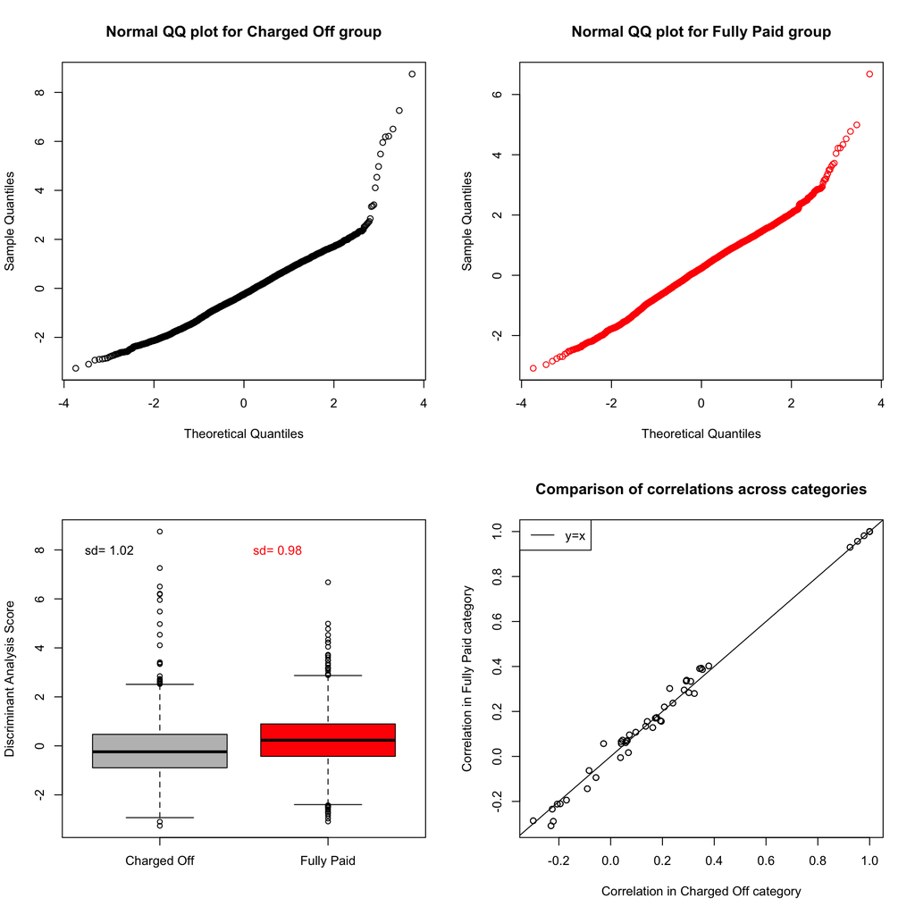

```r
lda(x=loans[,2:11], grouping= loans$Loans.loan_status)->loans.lda
predict(loans.lda)->loans.predict
par(mfrow=c(2,2))
qqnorm(loans.predict$x[loans$Loans.loan_status=="Charged Off"], main="Normal QQ plot for Charged Off group")
qqnorm(loans.predict$x[loans$Loans.loan_status=="Fully Paid"], main="Normal QQ plot for Fully Paid group", col=2)
boxplot(loans.predict$x~loans$Loans.loan_status, ylab="Discriminant Analysis Score", col=c("grey","red"))
text(0.7,8, paste("sd=", round(sd(loans.predict$x[loans$Loans.loan_status=="Charged Off"]),2)))
 text(1.7,8, paste("sd=", round(sd(loans.predict$x[loans$Loans.loan_status=="Fully Paid"]),2)), col=2)
plot(cor(loans[loans$Loans.loan_status=="Charged Off",2:11]), cor(loans[loans$Loans.loan_status=="Fully Paid",2:11]), xlab="Correlation in Charged Off category", ylab="Correlation in Fully Paid category", main="Comparison of correlations across categories")
legend("topleft", lty=1, legend="y=x")
abline(0,1)
```

Univariate plots of the orignial variables would not be inappropriate here, but would lead to the same conclusion which is that, although the group variances/covariances are very similar, there are some very heavy tails (big outliers, especially at the high end). Consequently we may question the appropriateness of posterior probabilities based on the normal distribution.

### Q6

```r
loadings.da<-matrix(NA, 10,1)
rownames(loadings.da)<-names(loans)[2:11]
for(i in 1:10) loadings.da[i]<-cor(loans[,i+1], loans.predict$x)
class(loadings.da)<-"loadings"
print(loadings.da, cutoff=0.2)
```

```
##
## Loadings:
##                   [,1]
## Loans.funded_amnt -0.299
## Loans.loan_amnt   -0.314
## Loans.dti         -0.246
## Loans.emp_length
## Loans.installment
## Loans.annual_inc   0.298
## Loans.revol_bal
## earlyear          -0.206
## proputil          -0.642
## Loans.open_acc
##
##                 [,1]
## SS loadings    0.823
## Proportion Var 0.082
```

Note that the “Charged off” category has lower scores on the discriminant component. The most important variable seems to be “proputil,” this is the proportion of all revolving credit accounts that is in use, with a high proportion leading to a lower score and higher probability the loan is “Charged Off.” Other variables related to the loan amount and other debt appear with negative coefficients; annual income has a positive coefficient as we would expect. “earlyear” is the year the person first took out credit, thus small numbers are further back in time. Establishing your first credit line more recently (larger year number) is also correlated with a lower score/ higher probability of “Charging Off.”

### Q7

```r
read.csv('loanprediction.csv')->loan.new
predict(loans.lda, newdata=loan.new[, 2:11], prior=c(0.14, 0.86))->new.predict
#posterior probability of the "Charged Off" class
round(new.predict$posterior[,1],2)
```

```
## [1] 0.19 0.11 0.12 0.08 0.17
```

None of the new data points has particularly high probability of being “charged off,” the largest is about 20%.

### Q8

Our primary deviation from normality in the discriminant function scores was some big outliers, so trying a t-based method seems like a good idea here.

### Q9

This code does leave-one-out cross validation and takes ages since we have over 10,000 data points.

```r
predictions<-matrix(NA, ncol=2, nrow=nrow(loans))
for(i in 1:nrow(loans)){
#  print(i)
mod<-qda(Loans.loan_status~.,data=loans[-i,2:12], method="t")
mod.predict<-predict(mod, newdata=loans[i,])
predictions[i,]<-mod.predict$posterior
}
```

Here is the code for 10 fold cross validation. This assigns a random number between 1 and 10 to each observation and this creates our 10 groups. One might do something fancier to 1) make sure the 10 groups are of exactly equal sizes and 2)make sure the 10 groups were equally split between charged off/fully paid. With this size of data I doubt it would make much difference. However there must be something *random* here–eg creating the 10 groups using the first 10th of the data, then the second, etc will mean each group is extremely unbalanced in charged off vs fully paid and will screw things up.

```r
predictions10<-rep(NA,  nrow=nrow(loans))
index<-sample( 1:10, nrow(loans),replace=TRUE)
for(j in 1:10){
mod<-qda(Loans.loan_status~.,data=loans[index!=j,2:12], method="t")
mod.predict<-predict(mod, newdata=loans[index==j,2:12])
predictions10[index==j]<-mod.predict$posterior[,1]
}
```

Ideally we would compare this to lda with 10-fold CV just to make sure we are comparing “apples with apples,” but I don’t expect you do do that. I took the (long) time to do leave one out CV for the QDA-t approach and compare with leave-one-out LDA below.

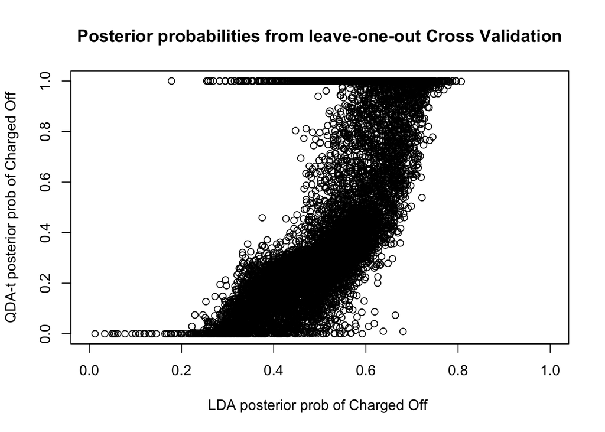

```r
plot(loans.lda.cv$posterior[,1], predictions[,1], xlab="LDA posterior prob of Charged Off ", ylab="QDA-t posterior prob of Charged Off", xlim=c(0,1), main="Posterior probabilities from leave-one-out Cross Validation")
```

```r
#This is just looking at whether the predicted class is the same as the observed class.  I could do it more directly if I had saved the predicted class rather than just the posterior probability.
round(sum((predictions[,1]> 0.5)== (loans$Loans.loan_status=="Charged Off") )/nrow(loans),2)
```

```
## [1] 0.56
```

The plot of the LDA posteriors vs the 10 fold cross validation posterior for QDA-t does look somewhat different–I have colored the points by which of the 10 different model fits was used for prediction, and this clearly has a systematic effect. However the overall message is the same–the QDA-t probabilities are more extreme (closer to 0/1), and the predicted accuracy is similar between the leave-one-out and 10-fold procedures.

Students need only one of these plot, or other sensible comparison of the methods, the corresponding error rate, and relevant comments.

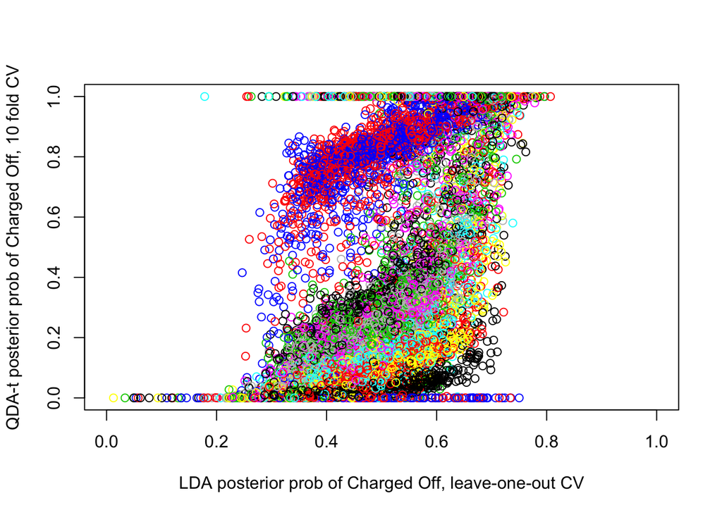

```r
 plot(loans.lda.cv$posterior[,1], predictions10, xlab="LDA posterior prob of Charged Off, leave-one-out CV", ylab="QDA-t posterior prob of Charged Off, 10 fold CV",col=index, xlim=c(0,1))
```

```r
round(sum((predictions10> 0.5)== (loans$Loans.loan_status=="Charged Off") )/nrow(loans),2)
```

```
## [1] 0.53
```